# Tema 9: Heterocedasticidad

Jorge Sosa-García

Primavera 2023

## 9.1. Heterocedastidad y sus Consecuencias

El supuesto RLM5 de **homocedasticidad** establece que
$$\mathrm{Var}[u | x_1, x_2, ..., x_k] =
\sigma^2$$
y se viola cuando la varianza del término de error (inobservables) cambia en la población en función de las variables explicativas consideradas.

Discutimos como los estimadores de MCO $\hat{\beta}_0, \hat{\beta}_1, \hat{\beta}_2, ..., \hat{\beta}_k$ son insesgados cuando se cumplen los primeros cuatro supuestos de Gauss-Markov. Además, bajo esos mismos cuatro supuestos estos estimadores son consistentes. Obsérvese que *el supuesto de homocedasticidad no es necesario para establecer ninguna de estas dos propiedades*.

Si podemos contar con estimadores insesgados y consistentes sin el supuesto de homocedasticidad, ¿para qué se necesita este supuesto? *El supuesto RLM5 se hizo para poder obtener estimadores insesgados de* $\mathrm{Var}[\hat{\beta}_j]$.

De esto se desprende que el supuesto de homocedasticidad es necesario para poder realizar pruebas de hipótesis pues, en presencia de **heterocedasticidad** los estadísticos $t$ y $F$ no siguen distribuciones $t$ y $F$, respectivamente.

Además, vimos que bajo los supuesto de Gauss-Markov, los estimadores de MCO son BLUE. Por tanto, si el término de error es heterocedástico, estos estimadores ya no son BLUE y tampoco son asintóticamente eficientes.

Debido a los problemas que induce la heterocedasticidad, necesitamos herramientas para diagnosticar su presencia y corregirla en los casos en que sea necesario.

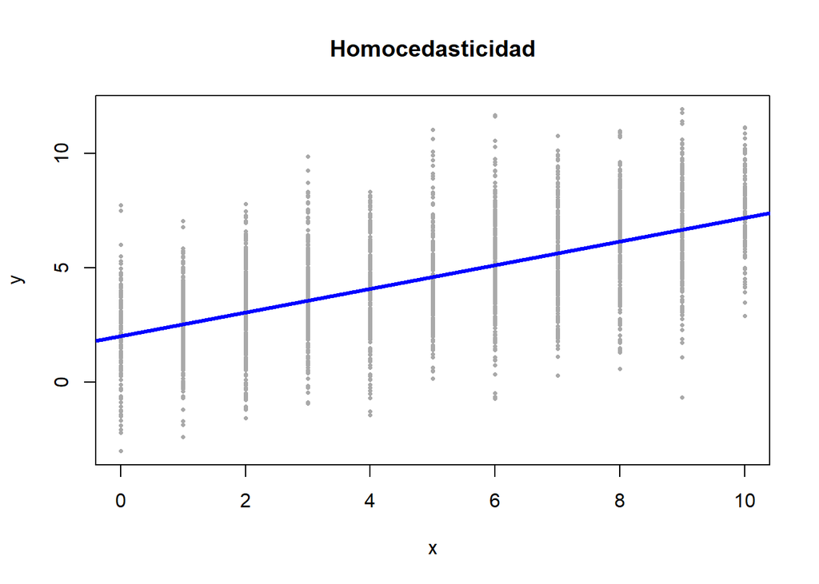

```r
# Replicabilidad
set.seed(700)

# Definicion de parametros
b0 <- 2
b1 <- 0.5
n <- 2500

# Variable explicativa
x <- round(runif(n, 0, 10), 0)

# Modelo homocedastico
u1 <- rnorm(n, 0, 2)
y1 <- b0 + b1 * x + u1
mod1 <- lm(y1 ~ x)
plot(x, y1,
     main = "Homocedasticidad",
     xlab = "x", ylab = "y",
     xlim = c(min(x), max(x)), ylim = c(min(y1), max(y1)),
     col = "darkgray", pch = 16, cex = 0.50)
abline(mod1, col = "blue", lwd = 3)
```

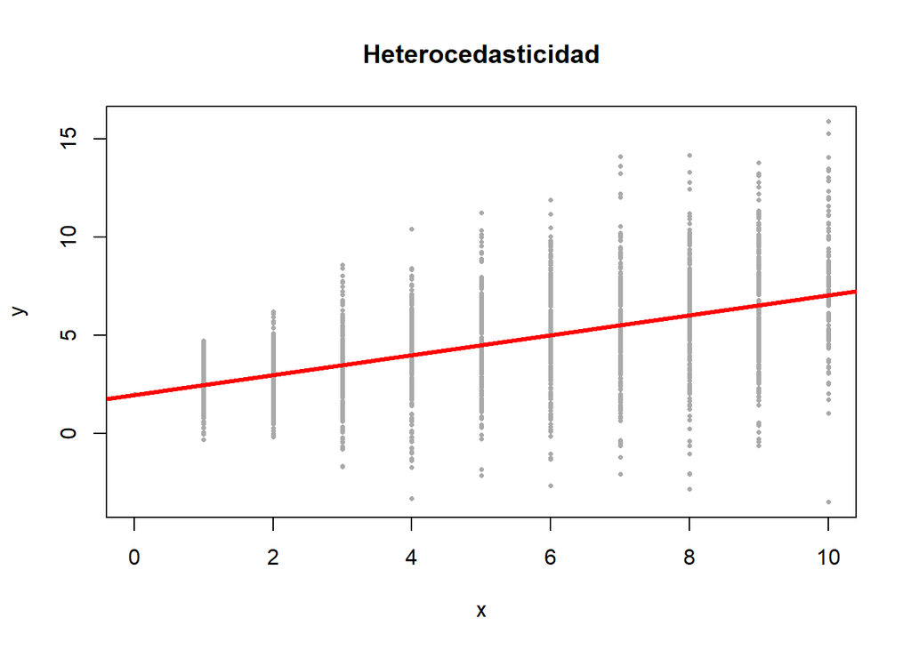

```r
# Modelo heterocedastico
u2 <- rnorm(n, 0, sqrt(x))
y2 <- b0 + b1 * x + u2
mod2 <- lm(y2 ~ x)
plot(x, y2,
     main = "Heterocedasticidad",
     xlab = "x", ylab = "y",
     xlim = c(min(x), max(x)), ylim = c(min(y2), max(y2)),
     col = "darkgray", pch = 16, cex = 0.50)
abline(mod2, col = "red", lwd = 3)
```

## 9.2. Pruebas de Detección de Heterocedasticidad

Empecemos desarrollando las ideas básicas detrás de las pruebas más comunes para detectar la presencia de heterocedasticidad en un modelo.

### 9.2.1. Prueba Breusch-Pagan

Suponga que tenemos el modelo lineal
$$y =
\beta_0 + \beta_1 x_1 + \beta_2 x_2 + ... + \beta_k x_k + u$$
que satisface los supuestos RLM1 a RLM4 (lo que nos permitirá tener estimadores insesgados y consistentes). En particular es de suma importancia que se cumpla el supuesto RLM3:
$$\mathrm{E}[u | x_1, x_2, ..., x_k] =
0$$

Partiremos del supuesto de que el modelo de interés cumple el supuesto de homocedasticidad y le preguntaremos a nuestra muestra aleatoria si hay evidencia de lo contrario. De esta manera, tomaremos como hipótesis nula de nuestra prueba:
$$H_0:
\: \mathrm{Var}[u | x_1, x_2, ..., x_k] = \sigma^2$$
Notemos que, dado que se RLM3, podemos expresar la hipótesis nula como:
$$H_0: \: \mathrm{Var}[u | x_1, x_2, ..., x_k] =
\mathrm{E}[u^2 | x_1, x_2, ..., x_k] = \mathrm{E}[u^2] =
\sigma^2$$
De esta manera, para detectar la presencia de heterocedasticidad deseamos probar si $u^2$ esta relacionada (en valor esperado) con alguna de nuestras variables explicativas. Una manera sencilla de explorar esta posibilidad es con un modelo lineal:
$$u^2 = \delta_0 + \delta_1 x_1 + \delta_2 x_2 +
... + \delta_k x_k + v$$
donde $v$ es un término de error con media cero.

De esta manera, la hipótesis nula de la prueba de detección de heterocedasticidad se puede reexpresar como:
$$H_0: \delta_1 = \delta_2 = ... = \delta_k =
0$$
Lo que señala que esta prueba es simplemente la prueba $F$ de significancia global de la regresión de $u^2$ sobre las variables explicativas.

Como nunca podemos conocer al término de error (ni sus cuadrados), la prueba anterior no se puede realizar. Sin embargo, esto se soluciona fácilmente cambiando $u^2$ por su contraparte muestral (que si conocemos) $\hat{u}^2$. Por lo que la prueba $F$ de significancia global se hace sobre la siguiente ecuación:
$$\hat{u}^2 = \delta_0
+ \delta_1 x_1 + \delta_2 x_2 + ... + \delta_k x_k + + v$$

Esta prueba se conoce como la **prueba Breusch-Pagan (BP)** de heterocedasticidad y se puede resumir en los siguientes pasos:

1. Establecer las hipótesis nula y alternativa:
   $$\begin{align*}
   H_0: &\: \text{El modelo es homocedástico}\\
   H_0: &\: \text{El modelo no es homocedástico}
   \end{align*}$$
2. Se estima la regresión de interés y se obtienen sus residuales cuadráticos $\hat{u}^2$.
3. Se estima la regresión de $\hat{u}^2$ sobre todas las variables explicativas consideradas.
4. Se calcula el estadístico $F$ de significancia global de esta segunda regresión (o el valor-$p$ del mismo estadístico).
5. Se concluye de acuerdo con el nivel de significancia establecido o con base en el valor-$p$ obtenido.  
   Rechazar $H_0$ indica la presencia de heterocedasticidad en el modelo (y se deben de tomar medidas correctivas).  
   Por su parte, no rechazar $H_0$ indica que el modelo satisface el supuesto RLM5.

### 9.2.2. Pruebas de White

Los errores estándar y estadísticos de prueba para los estimadores de MCO son asintóticamente válidos bajo los supuestos de Gauss-Markov tal como los presentamos. Sin embargo, el supuesto de homocedasticidad $\mathrm{Var}[u | x_1, x_2, ..., x_k] = \sigma^2$ puede ser reemplazado por el supuesto menos restrictivo de que el término de error (cuadrático) no esté correlacionado con ninguna de las variables explicativas $x_j$, ni con sus cuadrados $x_j^2$, ni con sus productos cruzados $x_j x_h$ para $j \neq h$.

Con esta nueva versión del supuesto RLM5 se puede desarrollar una prueba de detección de heterocedasticidad conocida como la **prueba de White**. Esta prueba está pensada para descartar formas de heterocedasticidad específicas que invaliden los errores estándar y estadísticos de prueba de los estimadores de MCO.

Para $k=3$, la prueba de White consiste en una vez que se tiene el modelo de interés estimado, se obtienen sus residuales cuadráticos para estimar la ecuación:
$$\hat{u}^2 = \delta_0 + \delta_1 x_1 + \delta_2
x_2 + \delta_3 x_3 + \delta_4 x_1^2 + \delta_5 x_2^2 + \delta_6 x_3^2 +
\delta_7 x_1 x_2 + \delta_8 x_1 x_3 + \delta_9 x_2 x_3 + v$$
y después realizar la prueba $F$ de significancia global de esta segunda regresión:
$$\begin{align*}
H_0: &\: \delta_1 = \delta_2 = ... = \delta_9 = 0 \\
H_1: &\: H_0 \text{ no es correcta}
\end{align*}$$

Notemos que, comparado con la prueba BP, la prueba de White incluye las relaciones cuadráticas de los regresores con los residuales cuadráticos, lo que afecta drásticamente a los grados de libertad de la prueba $F$ (con $k=3$ la prueba de White incluye 6 regresores más que la prueba BP), lo que puede impactar de manera importante la significancia de la prueba.

Un enfoque alternativo de esta prueba (conocida como pa **prueba de White simplificada**) se puede lograr recordando que los valores ajustados $\hat{y}$ son una función de las variables explicativas:
$$\hat{y}_1 = \hat{\beta}_0 +
\hat{\beta}_1 x_{1} + \hat{\beta}_2 x_{2} + ... + \hat{\beta}_k
x_{k}$$
Debido a esto, otra manera de incorporar las relaciones cuadráticas de los regresores con los residuales cuadráticos es con la ecuación:
$$\hat{u}^2 = \delta_0 + \delta_1
\hat{y}+ \delta_2 \hat{y}^2 + v$$

De esta manera, la prueba de White simplificada para detectar heterocedasticidad es simplemente la prueba $F$ de la siguiente hipótesis:
$$\begin{align*}
H_0: &\: \delta_1 = \delta_2 = 0 \\
H_1: &\: H_0 \text{ no es correcta}
\end{align*}$$

De esta manera, las pruebas de detección de heterocedasticidad de White y White simplificada se resumen como:

1. Establecer las hipótesis nula y alternativa:
   $$\begin{align*}
   H_0: &\: \text{El modelo es homocedástico}\\
   H_0: &\: \text{El modelo no es homocedástico}
   \end{align*}$$
2. Se estima la regresión de interés y se obtienen sus residuales cuadráticos $\hat{u}^2$ (si se realiza la prueba de White simplificada también se deben obtener los valores ajustados cuadráticos $\hat{y}^2$).
3. Para la prueba de White se estima la regresión de $\hat{u}^2$ sobre todas las variables explicativas consideradas y sus términos cuadráticos/cruzados. Para la prueba de White simplificada se estima la regresión de $\hat{u}^2$ sobre $\hat{y}$ e $\hat{y}^2$.
4. Se calcula el estadístico $F$ de los coeficientes relevantes (o el valor-$p$ del mismo estadístico).
5. Se concluye de acuerdo con el nivel de significancia establecido o con base en el valor-$p$ obtenido.  
   Rechazar $H_0$ indica la presencia de heterocedasticidad en el modelo (y se deben de tomar medidas correctivas).  
   Por su parte, no rechazar $H_0$ indica que el modelo satisface el supuesto RLM5.

## 9.3. Estimación e Inferencia con Heterocedasticidad

Considere el modelo siguiente modelo simple que satisface los primeros cuatro supuestos Gauss-Markov:
$$y_i
= \beta_0 + \beta_1 x_i + u_i$$

Si el modelo tiene errores heterocedásticos, entonces la varianza de estos se expresar como:
$$\mathrm{Var}[u_i |
x_{i1}, x_{i2}, ..., x_{{ik}}] = \sigma^2_i$$
Recordemos que el estimador de MCO del parámetro $\beta_1$ de este modelo se puede expresar como:
$$\hat{\beta}_1 = \beta_1 +
\frac{\sum_{i=1}^{n} (x_i - \bar{x}) u_i}{\sum_{i=1}^{n} (x_i -
\bar{x})^2}$$

Ahora, bajo RLM1-RLM4, y condicional sobre los valores muestrales $x_i$ tenemos:
$$\mathrm{Var}[\hat{\beta}_1] =
\frac{\sum_{i=1}^{n} (x_i - \bar{x})^2 \sigma^2_i}{SST_x^2}$$

Esta ecuación nos muestra que, para el modelo de regresión simple, la fórmula de la varianza para el estimador $\hat{\beta}_1$ que teníamos para el caso de errores homocedásticos ya no es válida en presencia de heterocedasticidad. Esto implica que el error estándar de $\hat{\beta}_1$ que nos permite realizar las pruebas $t$ y $F$ ya no es válido.

Debido a esto, necesitamos una manera de estima $\mathrm{Var}[\hat{\beta}_1]$ cuando el término de error es heterocedástico. Afrotunadamente, la última ecuación nos da una alternativa muy directa pues simplemente debemos usar los residuales $\hat{u}^2_i$ en lugar de $\sigma^2_i$. De esta manera, un estimador de $\mathrm{Var}[\hat{\beta}_1]$ válido en presencia de heterocedasticidad está dado por:
$$\frac{\sum_{i=1}^{n} (x_i - \bar{x})^2
\hat{u}^2_i}{SST_x^2}$$

Una fórmula similar se puede obtener para la regresión múltiple:
$$y = \beta_0 + \beta_1 x_1 + \beta_2 x_2 +
... + \beta_k x_k + u$$

En este caso, un estimador válido de la varianza de $\hat{\beta}_j$ en presencia de heterocedasticidad (suponiendo que los supuestos RLM1 a RLM4 se satisfacen) está dado por:
$$\mathrm{Var}(\hat{\beta}_j) =
\frac{\sum_{i=1}^{n} \hat{r}^2_{ij} \hat{u}^2_i}{SSR_j^2}$$
donde $\hat{r}_{ij}$ es el $i$-ésimo residual de la regresión de $x_j$ en las demás variables explicativas, y $SST_j$ *es la suma de los residuales al cuadrado de la misma regresión.

A partir de este estimador de $\mathrm{Var}[\hat{\beta}_j]$ se pueden calcular el error estándar de $\hat{\beta}_j$ que es válido pese a la heterocedasticidad, conocido como el **error estándar robusto a heterocedasticidad**. Este error estándar es que nos nos permite realizar inferencia estadística válida:

- Podemos obtener **el estadístico $t$ robusto a heterocedasticidad** de la misma manera que su versión homocedástica (usando el error estándar robusto):
  $$t = \frac{\hat{\beta}_j
  - a_j}{se(\hat{\beta}_j)}$$
- Podemos obtener el estadístico $F$ robusto a heterocedasticidad conocido como el **estadístico de Wald**

Dada la naturaleza de los dados económicos y de lo restrictivo del supuesto RLM5, lo más común es tener que hacer la corrección de heterocedasticidad a los errores estándar y estadísticos de prueba de un modelo.

Debido a esto, lo más común es presentar las versiones robustas de los errores y estadísticos aún sin evidencia estadística de que el término de error sea heterocedástico. Aún así, hay quienes prefieren no hacer esta corrección salvo en los casos en los que se tenga evidencia de heterocedasticidad.

La diferencia entre estas visiones radica en que, bajo homocedasticidad (y suponiendo que el término de error se distribuye normal) el estadístico $t$ y el estadístico $F$ siguen *distribuciones exactas* $t$ y $F$, respectivamente. Por el contrario, sus versiones robustas solo siguen esas *distribuciones de manera aproximada* en muestras grandes.

## 9.4. Ejemplos

Veamos algunos ejemplos de los conceptos cubiertos.

### 9.4.1. Prueba Breusch-Pagan

Construyamos un modelo para explicar el precio (miles de USD) de las casas en Estados Unidos. Para hacerlo, tomaremos como variables explicativas a:

- `lotsize`: tamaño del lote en el que está la casa.
- `sqrft`: tamaño construido de la casa.
- `bdrms`: número de habitaciones.

Por ahora nuestro interés no está en la interpretación de los resultados obtenidos, sino en las pruebas que se pueden realizar sobre el modelo para identificar la presencia de heterocedasticidad en el término de error. Es importante destacar que no hay un criterio para saber cuando es conveniente (y cuando no lo es) realizar una prueba de detección de heterocedasticidad.

Por lo general, es la experiencia del investigador la que suele servir como referencia para determinar si se realiza o no una prueba de detección de heterocedasticidad. En el peor de los casos, siempre se pueden reportar los errores estándar robustos, aunque no se haya realizado la prueba de detección, sin que esto invalide nuestros resultados.

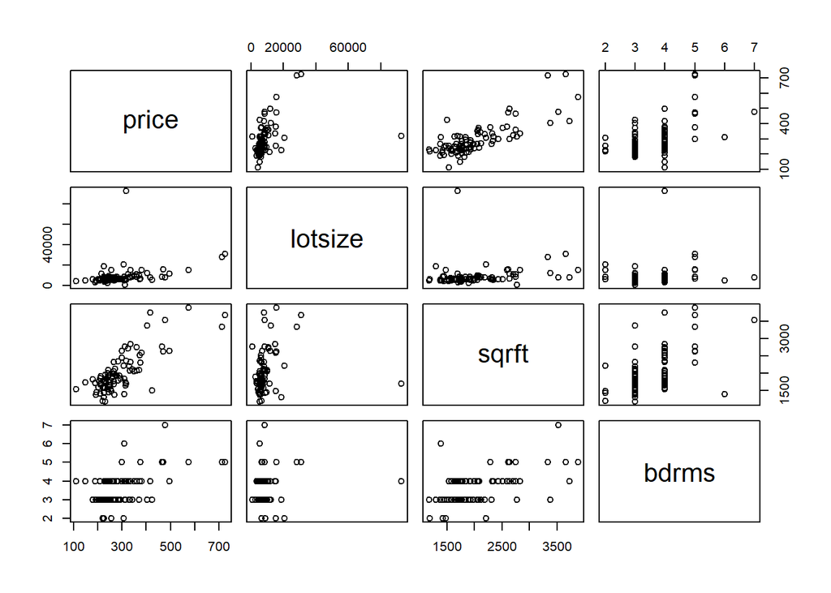

```r
# Carga base de datos
data(hprice1)

# Seleccion de variables relevantes
base1 <- select(hprice1,
                price, lotsize, sqrft, bdrms)

# Grafica base
plot(base1)
```

```r
# Estimacion del modelo
modelo_casas <- lm(formula = price ~ lotsize + sqrft + bdrms,
                   data = base1)

# Presentación de resultados
stargazer(modelo_casas, digits =3,
          type = "text", style = "io",
          dep.var.labels = c("Precio"),
          covariate.labels = c("Tamaño Lote", "Tamaño Construcción",
                               "Número de Habitaciones", "Constante"))
```

```
##
## ------------------------------------------------------
##                                     Precio
## ------------------------------------------------------
## Tamaño Lote                        0.002***
##                                    (0.001)
## Tamaño Construcción                0.123***
##                                    (0.013)
## Número de Habitaciones              13.853
##                                    (9.010)
## Constante                          -21.770
##                                    (29.475)
## Observations                          88
## R-squared                           0.672
## Adjusted R-squared                  0.661
## Residual standard error        59.833 (df = 84)
## F statistic                 57.460*** (df = 3; 84)
## ------------------------------------------------------
## Notes:                  ***p < .01; **p < .05; *p < .1
```

Por ahora, los resultados no son de nuestro interés pues lo que deseamos es saber si este modelo presenta evidencias de heterocedasticidad en su término de error. Para esto, realizamos una prueba de Breusch-Pagan como sigue:

```r
# Paso 1:
# Recuperar los residuales al cuadrado
u2 <- resid(modelo_casas)^2

# Paso 2:
# Regresion auxiliar de los residuales
reg_auxiliar <- lm(formula = u2 ~ lotsize + sqrft + bdrms,
                   data = base1)

# Paso 3:
# Conclusion con estadistico F/valor-p
stargazer(reg_auxiliar, digits = 3,
          type = "text", style = "io",
          dep.var.labels = c("Residuales Cuadrados"),
          covariate.labels = c("Tamaño Lote", "Tamaño Construcción",
                               "Número de Habitaciones", "Constante"))
```

```
##
## ------------------------------------------------------
##                              Residuales Cuadrados
## ------------------------------------------------------
## Tamaño Lote                        0.202***
##                                    (0.071)
## Tamaño Construcción                 1.691
##                                    (1.464)
## Número de Habitaciones            1,041.760
##                                   (996.381)
## Constante                        -5,522.795*
##                                  (3,259.478)
## Observations                          88
## R-squared                           0.160
## Adjusted R-squared                  0.130
## Residual standard error      6,616.646 (df = 84)
## F statistic                 5.339*** (df = 3; 84)
## ------------------------------------------------------
## Notes:                  ***p < .01; **p < .05; *p < .1
```

Tenemos que el estadístico $F$ de la preba de significancia global de la regresión auxiliar es de 5.339 y su valor-$p$ es de 0.002.

Este valor del estadístico y del valor-$p$ de la prueba de significancia global nos llevan a rechazar la hipótesis nula, que en el caso de la prueba Breusch-Pagan es que el modelo cumple el supuesto RLM5.

Por tanto, al rechazar la hipótesis nula, estamos encontrando evidencia de que el modelo sufre de heterocedasticidad y, por tanto, se deberían tomar medidas correctivas, como el uso de errores estándar robustos.

### 9.4.2. Pruebas de White

Continuemos con el modelo anterior donde se buscaba explicar el precio de una casa con base en algunas de sus características de tamaño y número de habitaciones.

Una vez más, por ahora nuestro interés no está en la interpretación de los resultados obtenidos, sino en las pruebas que se pueden realizar sobre el modelo para identificar la presencia de heterocedasticidad en el término de error.

Empezaremos realizando la prueba de White, la cual analiza la relación existente entre el término de error y los términos cuadráticos/cruzados de las variables explicativas para determinar la presencia de heterocedasticidad. Esta prueba se realiza como sigue:

```r
# Paso 1:
# Recuperar los residuales al cuadrado
u2 <- resid(modelo_casas)^2

# Paso 2:
# Regresion auxiliar de los residuales
aux_white <- lm(formula = u2 ~ lotsize + sqrft + bdrms +
                  I(lotsize^2) + I(sqrft^2) + I(bdrms^2) +
                  lotsize * sqrft +
                  lotsize * bdrms +
                  sqrft * bdrms,
                data = base1)

# Paso 3:
# Conclusion con estadistico F/valor-p
stargazer(aux_white, digits = 3,
          type = "text", style = "io",
          dep.var.labels = c("Residuales Cuadrados"),
          covariate.labels = c("Tamaño Lote", "Tamaño Construcción",
                               "Número de Habitaciones",
                               "Tamaño Lote-SQ", "Tamaño Construcción-SQ",
                               "Número de Habitaciones-SQ",
                               "Lote * Construcción", "Lote * Habitaciones",
                               "Construcción * Habitaciones", "Constante"))
```

```
##
## ----------------------------------------------------------
##                                  Residuales Cuadrados
## ----------------------------------------------------------
## Tamaño Lote                           -1.860***
##                                        (0.637)
## Tamaño Construcción                     -2.674
##                                        (8.662)
## Número de Habitaciones                -1,982.841
##                                      (5,438.483)
## Tamaño Lote-SQ                         -0.00000
##                                       (0.00000)
## Tamaño Construcción-SQ                  0.0004
##                                        (0.002)
## Número de Habitaciones-SQ              289.754
##                                       (758.830)
## Lote * Construcción                     0.0005
##                                        (0.0003)
## Lote * Habitaciones                     0.315
##                                        (0.252)
## Construcción * Habitaciones             -1.021
##                                        (1.667)
## Constante                             15,626.240
##                                      (11,369.410)
## Observations                              88
## R-squared                               0.383
## Adjusted R-squared                      0.312
## Residual standard error          5,883.814 (df = 78)
## F statistic                     5.387*** (df = 9; 78)
## ----------------------------------------------------------
## Notes:                      ***p < .01; **p < .05; *p < .1
```

Tenemos que el estadístico $F$ de la preba de significancia global de la regresión auxiliar es de 5.387 y su valor-$p$ es de 0.00001013.

Este valor del estadístico y del valor-$p$ de la prueba de significancia global nos llevan a rechazar la hipótesis nula, que en el caso de la prueba de White es que el modelo cumple el supuesto RLM5.

Por tanto, al rechazar la hipótesis nula, estamos encontrando evidencia de que el modelo sufre de heterocedasticidad.

Notemos que esta prueba tiene algunos. Primero, requiere incorporar muchos regresores y es fácil equivocarse al omitir alguno de ellos. Segundo, al incorporar tantos regresores afecta los grados de libertad de la prueba $F$.

Para resolver estos problemas, se cuenta con la prueba de White simplificada. Esta prueba también sirve para detectar heterocedasticidad pero usa los valores ajustados de la regresión en lugar de los regresores para encontrar relaciones entre los residuales y las variables explicativas.

```r
# Paso 1:
# Recuperar los residuales al cuadrado y valores ajustados
u2 <- resid(modelo_casas)^2
y_hat <- fitted(modelo_casas)

# Paso 2:
# Regresión auxiliar de residuales y valores ajustados
aux_whitesimp <- lm(formula = u2 ~ y_hat + I(y_hat^2))

# Paso 3:
# Conclusion con estadistico F/valor-p
stargazer(aux_whitesimp, digits = 3,
          type = "text", style = "io",
          dep.var.labels = c("Residuales Cuadrados"),
          covariate.labels = c("Ajustados", "Ajustados-SQ",
                               "Constante"))
```

```
##
## ------------------------------------------------------
##                              Residuales Cuadrados
## ------------------------------------------------------
## Ajustados                         -119.655**
##                                    (53.317)
## Ajustados-SQ                       0.209***
##                                    (0.075)
## Constante                        19,071.590**
##                                  (8,876.227)
## Observations                          88
## R-squared                           0.185
## Adjusted R-squared                  0.166
## Residual standard error      6,480.055 (df = 85)
## F statistic                 9.639*** (df = 2; 85)
## ------------------------------------------------------
## Notes:                  ***p < .01; **p < .05; *p < .1
```

Tenemos que el estadístico $F$ de la preba de significancia global de la regresión auxiliar es de 9.639 y su valor-$p$ es de 0.0001687.

Este valor del estadístico y del valor-$p$ de la prueba de significancia global nos llevan a rechazar la hipótesis nula, que en el caso de la prueba de White simplificada es que el modelo cumple el supuesto RLM5.

Por tanto, al rechazar la hipótesis nula, estamos encontrando evidencia de que el modelo sufre de heterocedasticidad y, por tanto, debemos tomar medidas correctivas.

### 9.4.3. Errores Estándar e Inferencia Robusta a Heterocedasticidad

Continuando con el modelo de los ejemplos anteriores, los resultados del modelo estimado son:

```r
# Presentación de resultados
stargazer(modelo_casas, digits =3,
          type = "text", style = "io",
          dep.var.labels = c("Precio"),
          covariate.labels = c("Tamaño Lote", "Tamaño Construcción",
                               "Número de Habitaciones", "Constante"))
```

```
##
## ------------------------------------------------------
##                                     Precio
## ------------------------------------------------------
## Tamaño Lote                        0.002***
##                                    (0.001)
## Tamaño Construcción                0.123***
##                                    (0.013)
## Número de Habitaciones              13.853
##                                    (9.010)
## Constante                          -21.770
##                                    (29.475)
## Observations                          88
## R-squared                           0.672
## Adjusted R-squared                  0.661
## Residual standard error        59.833 (df = 84)
## F statistic                 57.460*** (df = 3; 84)
## ------------------------------------------------------
## Notes:                  ***p < .01; **p < .05; *p < .1
```

Sin embargo, con las pruebas de Breusch-Pagan, White y White simplificada hemos detectado la presencia de heterocedasticidad en el modelo lo que, si bien no invalida completamente la validez de los coeficientes estimados, si imposibilita realizar pruebas de hipótesis e inferencia estadística sobre los mismos.

Para poder hacer las pruebas de hipótesis que nos interesan debemos modificar los errores estándar del modelo estimado, corrigiéndolos por la presencia de heterocedasticidad.

Para hacer esto, necesitamos 3 “tablas auxiliares”:

```r
# Modelo base
(clasico <- coeftest(modelo_casas))
```

```
##
## t test of coefficients:
##
##                Estimate  Std. Error t value  Pr(>|t|)
## (Intercept) -2.1770e+01  2.9475e+01 -0.7386  0.462208
## lotsize      2.0677e-03  6.4213e-04  3.2201  0.001823 **
## sqrft        1.2278e-01  1.3237e-02  9.2751 1.658e-14 ***
## bdrms        1.3853e+01  9.0101e+00  1.5374  0.127945
## ---
## Signif. codes:  0 '***' 0.001 '**' 0.01 '*' 0.05 '.' 0.1 ' ' 1
```

```r
# Modelo BP
(bp <- coeftest(modelo_casas,
                vcov = hccm(modelo_casas, type = "hc2")))
```

```
##
## t test of coefficients:
##
##                Estimate  Std. Error t value  Pr(>|t|)
## (Intercept) -21.7703081  38.3812759 -0.5672    0.5721
## lotsize       0.0020677   0.0028735  0.7196    0.4738
## sqrft         0.1227782   0.0225638  5.4414 5.124e-07 ***
## bdrms        13.8525217   9.1866384  1.5079    0.1353
## ---
## Signif. codes:  0 '***' 0.001 '**' 0.01 '*' 0.05 '.' 0.1 ' ' 1
```

```r
# Modelo White
(white <- coeftest(modelo_casas,
                   vcov = hccm(modelo_casas, type = "hc0")))
```

```
##
## t test of coefficients:
##
##                Estimate  Std. Error t value  Pr(>|t|)
## (Intercept) -21.7703081  36.2843444 -0.6000   0.55013
## lotsize       0.0020677   0.0012227  1.6912   0.09451 .
## sqrft         0.1227782   0.0173178  7.0897 3.883e-10 ***
## bdrms        13.8525217   8.2836880  1.6723   0.09819 .
## ---
## Signif. codes:  0 '***' 0.001 '**' 0.01 '*' 0.05 '.' 0.1 ' ' 1
```

```r
# Modelo White simplificado
(whitesimp <- coeftest(modelo_casas,
                       vcov = hccm))
```

```
##
## t test of coefficients:
##
##                Estimate  Std. Error t value Pr(>|t|)
## (Intercept) -21.7703081  41.0326943 -0.5306 0.597124
## lotsize       0.0020677   0.0071485  0.2893 0.773101
## sqrft         0.1227782   0.0407325  3.0143 0.003406 **
## bdrms        13.8525217  11.5617901  1.1981 0.234236
## ---
## Signif. codes:  0 '***' 0.001 '**' 0.01 '*' 0.05 '.' 0.1 ' ' 1
```

Con las tablas definidas, presentamos los resultados con las clases de errores estándar (“clásicos”, BP, White y White Simplificado):

```r
# Presentacion de resultados
stargazer(clasico, bp, white, whitesimp,
          digits = 5, type = "text", style = "io",
          dep.var.labels = c("Precio"),
          covariate.labels = c("Tamaño Lote",
                               "Tamaño Construcción",
                               "Número de Habitaciones",
                               "Constante"),
          column.labels = c("Clásico", "Breusch-Pagan",
                            "White", "White Simplificado"))
```

```
##
## -----------------------------------------------------------------------------
##                                                Precio
##                         Clásico   Breusch-Pagan   White    White Simplificado
##                           (1)          (2)         (3)            (4)
## -----------------------------------------------------------------------------
## Tamaño Lote            0.00207***    0.00207     0.00207*       0.00207
##                        (0.00064)    (0.00287)   (0.00122)      (0.00715)
## Tamaño Construcción    0.12278***  0.12278***   0.12278***     0.12278***
##                        (0.01324)    (0.02256)   (0.01732)      (0.04073)
## Número de Habitaciones  13.85252    13.85252    13.85252*       13.85252
##                        (9.01015)    (9.18664)   (8.28369)      (11.56179)
## Constante              -21.77031    -21.77031   -21.77031      -21.77031
##                        (29.47504)  (38.38128)   (36.28434)     (41.03269)
## -----------------------------------------------------------------------------
## Notes:                 ***p < .01; **p < .05; *p < .1
```

De la tabla es importante notar lo siguiente:

- Los coeficientes estimados no cambian.
- Los errores estándar son distintos en las cuatro columnas.  
  Aunque estas diferencias normalmente son pequeñas, pueden ser lo suficientemente importantes como para cambiar las conclusiones de algunas pruebas de hipótesis, especialmente si se está usando un grado de significancia alto.

Una vez que se ha hecho la corrección por heterocedasticidad de los errores estándar, podemos realizar la inferencia estadística de la forma habitual. Por ejemplo, supongamos que queremos hacer la siguiente prueba al 1% de significancia:
$$\begin{align*}
H_0: &\: \beta_1 = 0 \\
H_1: &\: \beta_1 \neq 0
\end{align*}$$

Sin corrección por heterocedasticidad tenemos:

- Coeficiente estimado: 0.00207
- Error estándar: 0.00064
- Estadístico $t$: 3.2201
- Valor-$p$ de la prueba: 0.00182
- Conclusión: Se rechaza $H_0$

Con corrección BP:

- Coeficiente estimado: 0.00207
- Error estándar: 0.00287
- Estadístico $t$: 0.71957
- Valor-$p$ de la prueba: 0.47378
- Conclusión: No se rechaza $H_0$

Con corrección de White:

- Coeficiente estimado: 0.00207
- Error estándar: 0.00122
- Estadístico $t$: 1.69117
- Valor-$p$ de la prueba: 0.09451
- Conclusión: No se rechaza $H_0$

Con corrección de White simplificada:

- Coeficiente estimado: 0.00207
- Error estándar: 0.00715
- Estadístico $t$: 0.28925
- Valor-$p$ de la prueba: 0.7731
- Conclusión: No se rechaza $H_0$

## 9.5. Ejercicios

1. Considere la base de datos en `hprice1` para estimar la siguiente ecuación:
   $$price = \beta_0 +
   \beta_1 \: lotsize + \beta_2 \: sqrft + \beta_3 \: bdrms + u$$
   1. Estime el modelo y presente los resultados sin y con corrección por heterocedasticidad en los errores estándar. Discuta cualquier diferencia importante que encuentre entre los modelos.
   2. Repita el inciso anterior pero estimando el modelo que usa las versiones logarítmicas de todas las variables (excepto `bdrms`).
   3. Compare los resultados obtenidos en los incisos anteriores. ¿Que le sugiere esto sobre la heterocedasticidas y la transformación de las variables usadas en los modelos?
2. Considere la base de datos en `vote1` para estimar el siguiente modelo:
   $$voteA = \beta_0 + \beta_1
   \: prtystrA + \beta_2 \: democA + \beta_3 \: \ln(expendA) + \beta_4 \:
   \ln(expendB) + u$$
   1. Estime el modelo y obtenga los residuales. Haga la regresión de los residuales sobre todas las variables explicativas consideradas. ¿Por qué se obtiene una $R^2=0$ en esta segunda regresión?
   2. Realice la prueba BP de heterocedasticidad de este modelo. Use la versión del estadístico $F$ y reporte el valor-$p$ de la prueba. ¿Hay evidencia de heterocedasticidad en el modelo?
   3. Realice la prueba de White simplificada de heterocedasticidad. Use la versión del estadístico $F$. ¿Hay evidencia de heterocedasticidad en el modelo?